# Ejercicio 5 tarea

Abraham Nieto 51556

28 de octubre de 2017

llamamos toolset,utils,metadata,load y prepare

```r
source('toolset.R')
source('utils.R')
source('metadata.R')
source('00-load.R')
source('01-prepare.R')
```

Ahora usamos summary para verla estructura de los datos…

```r
str(algas)
```

```
## Classes 'tbl_df', 'tbl' and 'data.frame':    200 obs. of  18 variables:
##  $ season        : chr  "winter" "spring" "autumn" "spring" ...
##  $ river_size    : chr  "small_" "small_" "small_" "small_" ...
##  $ fluid_velocity: chr  "medium" "medium" "medium" "medium" ...
##  $ max_ph        : num  8 8.35 8.1 8.07 8.06 8.25 8.15 8.05 8.7 7.93 ...
##  $ min_o2        : num  9.8 8 11.4 4.8 9 13.1 10.3 10.6 3.4 9.9 ...
##  $ cl            : num  60.8 57.8 40 77.4 55.4 ...
##  $ no3           : chr  "6.23800" "1.28800" "5.33000" "2.30200" ...
##  $ nh4           : num  578 370 346.7 98.2 233.7 ...
##  $ opo4          : num  105 428.8 125.7 61.2 58.2 ...
##  $ po4           : num  170 558.8 187.1 138.7 97.6 ...
##  $ chla          : num  50 1.3 15.6 1.4 10.5 ...
##  $ a1            : num  0 1.4 3.3 3.1 9.2 15.1 2.4 18.2 25.4 17 ...
##  $ a2            : num  0 7.6 53.6 41 2.9 14.6 1.2 1.6 5.4 0 ...
##  $ a3            : num  0 4.8 1.9 18.9 7.5 1.4 3.2 0 2.5 0 ...
##  $ a4            : num  0 1.9 0 0 0 0 3.9 0 0 2.9 ...
##  $ a5            : num  34.2 6.7 0 1.4 7.5 22.5 5.8 5.5 0 0 ...
##  $ a6            : num  8.3 0 0 0 4.1 12.6 6.8 8.7 0 0 ...
##  $ a7            : num  0 2.1 9.7 1.4 1 2.9 0 0 0 1.7 ...
##  - attr(*, "problems")=Classes 'tbl_df', 'tbl' and 'data.frame': 17 obs. of  5 variables:
##   ..$ row     : int  20 21 34 35 36 69 70 71 88 89 ...
##   ..$ col     : chr  NA NA NA NA ...
##   ..$ expected: chr  "18 columns" "18 columns" "18 columns" "18 columns" ...
##   ..$ actual  : chr  "17 columns" "17 columns" "17 columns" "17 columns" ...
##   ..$ file    : chr  "'https://archive.ics.uci.edu/ml/machine-learning-databases/coil-mld/analysis.data'" "'https://archive.ics.uci.edu/ml/machine-learning-databases/coil-mld/analysis.data'" "'https://archive.ics.uci.edu/ml/machine-learning-databases/coil-mld/analysis.data'" "'https://archive.ics…
##  - attr(*, "spec")=List of 2
##   ..$ cols   :List of 18
##   .. ..$ season        : list()
##   .. .. ..- attr(*, "class")= chr  "collector_character" "collector"
##   .. ..$ river_size    : list()
##   .. .. ..- attr(*, "class")= chr  "collector_character" "collector"
##   .. ..$ fluid_velocity: list()
##   .. .. ..- attr(*, "class")= chr  "collector_character" "collector"
##   .. ..$ max_PH        : list()
##   .. .. ..- attr(*, "class")= chr  "collector_double" "collector"
##   .. ..$ min_O2        : list()
##   .. .. ..- attr(*, "class")= chr  "collector_double" "collector"
##   .. ..$ Cl            : list()
##   .. .. ..- attr(*, "class")= chr  "collector_double" "collector"
##   .. ..$ NO3           : list()
```

[output cut: 11 more lines]

```
##   .. ..$ a2            : list()
##   .. .. ..- attr(*, "class")= chr  "collector_double" "collector"
##   .. ..$ a3            : list()
##   .. .. ..- attr(*, "class")= chr  "collector_double" "collector"
##   .. ..$ a4            : list()
##   .. .. ..- attr(*, "class")= chr  "collector_double" "collector"
##   .. ..$ a5            : list()
##   .. .. ..- attr(*, "class")= chr  "collector_double" "collector"
##   .. ..$ a6            : list()
##   .. .. ..- attr(*, "class")= chr  "collector_double" "collector"
##   .. ..$ a7            : list()
##   .. .. ..- attr(*, "class")= chr  "collector_double" "collector"
##   ..$ default: list()
##   .. ..- attr(*, "class")= chr  "collector_guess" "collector"
##   ..- attr(*, "class")= chr "col_spec"
```

```r
summary(algas)
```

```
##     season           river_size        fluid_velocity         max_ph
##  Length:200         Length:200         Length:200         Min.   :5.600
##  Class :character   Class :character   Class :character   1st Qu.:7.700
##  Mode  :character   Mode  :character   Mode  :character   Median :8.060
##                                                           Mean   :8.012
##                                                           3rd Qu.:8.400
##                                                           Max.   :9.700
##                                                           NA's   :1
##      min_o2             cl              no3                 nh4
##  Min.   : 1.500   Min.   :  0.222   Length:200         Min.   :  5.00
##  1st Qu.: 7.725   1st Qu.: 10.981   Class :character   1st Qu.: 35.62
##  Median : 9.800   Median : 32.730   Mode  :character   Median : 99.67
##  Mean   : 9.118   Mean   : 43.636                      Mean   :154.45
##  3rd Qu.:10.800   3rd Qu.: 57.824                      3rd Qu.:203.73
##  Max.   :13.400   Max.   :391.500                      Max.   :931.83
##  NA's   :2        NA's   :10                           NA's   :2
##       opo4             po4              chla              a1
##  Min.   :  1.00   Min.   :  0.90   Min.   :  0.00   Min.   : 0.000
##  1st Qu.: 16.00   1st Qu.: 19.39   1st Qu.:  2.00   1st Qu.: 1.475
##  Median : 41.40   Median : 84.50   Median :  5.20   Median : 7.400
##  Mean   : 83.33   Mean   :111.55   Mean   : 13.54   Mean   :16.863
##  3rd Qu.:102.25   3rd Qu.:182.16   3rd Qu.: 18.30   3rd Qu.:24.075
##  Max.   :771.60   Max.   :558.75   Max.   :110.46   Max.   :89.800
##  NA's   :2        NA's   :2        NA's   :12
##        a2               a3               a4               a5
##  Min.   : 0.000   Min.   : 0.000   Min.   : 0.000   Min.   : 0.00
##  1st Qu.: 0.000   1st Qu.: 0.000   1st Qu.: 0.000   1st Qu.: 0.00
##  Median : 2.100   Median : 1.750   Median : 0.000   Median : 1.90
##  Mean   : 6.934   Mean   : 4.729   Mean   : 1.885   Mean   : 5.63
##  3rd Qu.: 9.075   3rd Qu.: 6.150   3rd Qu.: 2.225   3rd Qu.: 7.70
##  Max.   :72.600   Max.   :44.600   Max.   :35.600   Max.   :77.60
##
##        a6               a7
##  Min.   : 0.000   Min.   : 0.000
##  1st Qu.: 0.000   1st Qu.: 0.000
##  Median : 0.000   Median : 0.000
##  Mean   : 5.199   Mean   : 2.506
##  3rd Qu.: 6.725   3rd Qu.: 2.400
##  Max.   :52.500   Max.   :31.600
##                   NA's   :17
```

llamamos 02-clean y expllicamos todo lo que se hizo…

```r
source('02-clean.R')
```

```
## Observations: 200
## Variables: 18
## $ season         <chr> "winter", "spring", "autumn", "spring", "autumn...
## $ river_size     <chr> "small_", "small_", "small_", "small_", "small_...
## $ fluid_velocity <chr> "medium", "medium", "medium", "medium", "medium...
## $ max_ph         <dbl> 8.00, 8.35, 8.10, 8.07, 8.06, 8.25, 8.15, 8.05,...
## $ min_o2         <dbl> 9.8, 8.0, 11.4, 4.8, 9.0, 13.1, 10.3, 10.6, 3.4...
## $ cl             <dbl> 60.800, 57.750, 40.020, 77.364, 55.350, 65.750,...
## $ no3            <dbl> 6.238, 1.288, 5.330, 2.302, 10.416, 9.248, 1.53...
## $ nh4            <dbl> 578.000, 370.000, 346.667, 98.182, 233.700, 430...
## $ opo4           <dbl> 105.000, 428.750, 125.667, 61.182, 58.222, 18.2...
## $ po4            <dbl> 170.000, 558.750, 187.057, 138.700, 97.580, 56....
## $ chla           <dbl> 50.000, 1.300, 15.600, 1.400, 10.500, 28.400, 3...
## $ a1             <dbl> 0.0, 1.4, 3.3, 3.1, 9.2, 15.1, 2.4, 18.2, 25.4,...
## $ a2             <dbl> 0.0, 7.6, 53.6, 41.0, 2.9, 14.6, 1.2, 1.6, 5.4,...
## $ a3             <dbl> 0.0, 4.8, 1.9, 18.9, 7.5, 1.4, 3.2, 0.0, 2.5, 0...
## $ a4             <dbl> 0.0, 1.9, 0.0, 0.0, 0.0, 0.0, 3.9, 0.0, 0.0, 2....
## $ a5             <dbl> 34.2, 6.7, 0.0, 1.4, 7.5, 22.5, 5.8, 5.5, 0.0, ...
## $ a6             <dbl> 8.3, 0.0, 0.0, 0.0, 4.1, 12.6, 6.8, 8.7, 0.0, 0...
## $ a7             <dbl> 0.0, 2.1, 9.7, 1.4, 1.0, 2.9, 0.0, 0.0, 0.0, 1....
```

[output not shown]

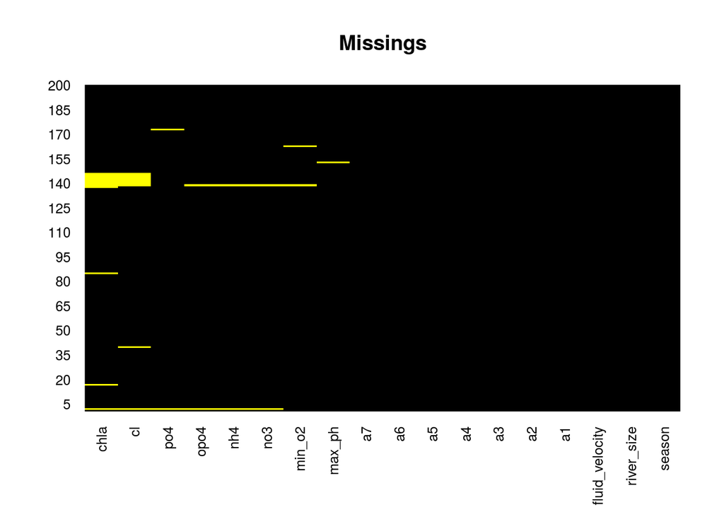

```
## # A tibble: 16 x 8
##    max_ph min_o2    cl   no3   nh4    opo4     po4  chla
##     <dbl>  <dbl> <dbl> <dbl> <dbl>   <dbl>   <dbl> <dbl>
##  1   6.80   11.1 9.000 0.630    20   4.000      NA  2.70
##  2   8.00     NA 1.450 0.810    10   2.500   3.000  0.30
##  3     NA   12.6 9.000 0.230    10   5.000   6.000  1.10
##  4   6.60   10.8    NA 3.245    10   1.000   6.500    NA
##  5   5.60   11.8    NA 2.220     5   1.000   1.000    NA
##  6   5.70   10.8    NA 2.550    10   1.000   4.000    NA
##  7   6.60    9.5    NA 1.320    20   1.000   6.000    NA
##  8   6.60   10.8    NA 2.640    10   2.000  11.000    NA
##  9   6.60   11.3    NA 4.170    10   1.000   6.000    NA
## 10   6.50   10.4    NA 5.970    10   2.000  14.000    NA
## 11   6.40     NA    NA    NA    NA      NA  14.000    NA
## 12   7.83   11.7 4.083 1.328    18   3.333   6.667    NA
## 13   9.70   10.8 0.222 0.406    10  22.444  10.111    NA
## 14   9.00    5.8    NA 0.900   142 102.000 186.000 68.05
## 15   8.00   10.9 9.055 0.825    40  21.083  56.091    NA
## 16   8.00    7.6    NA    NA    NA      NA      NA    NA
```

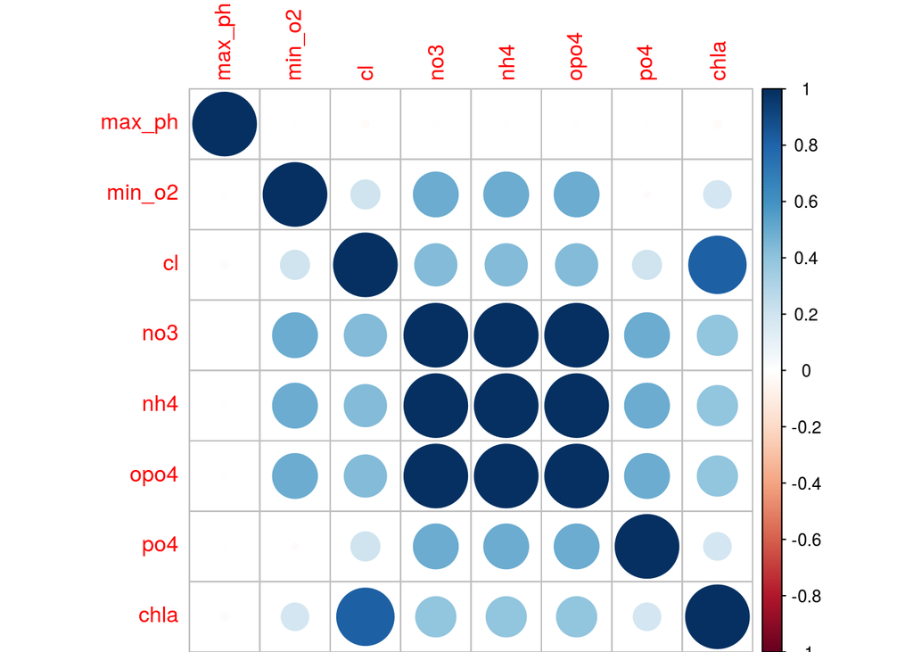

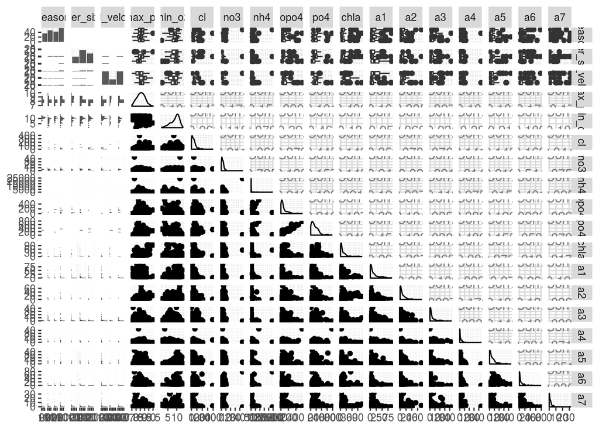

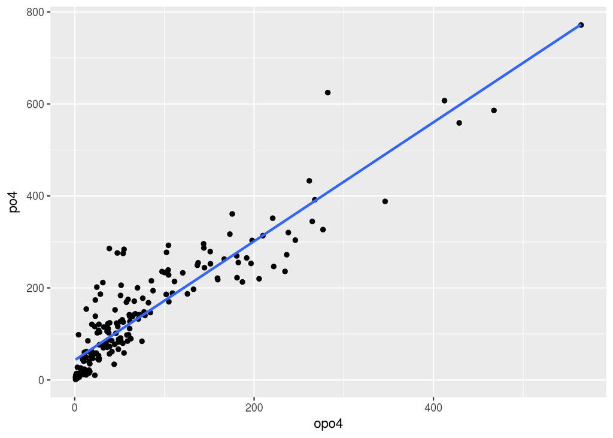

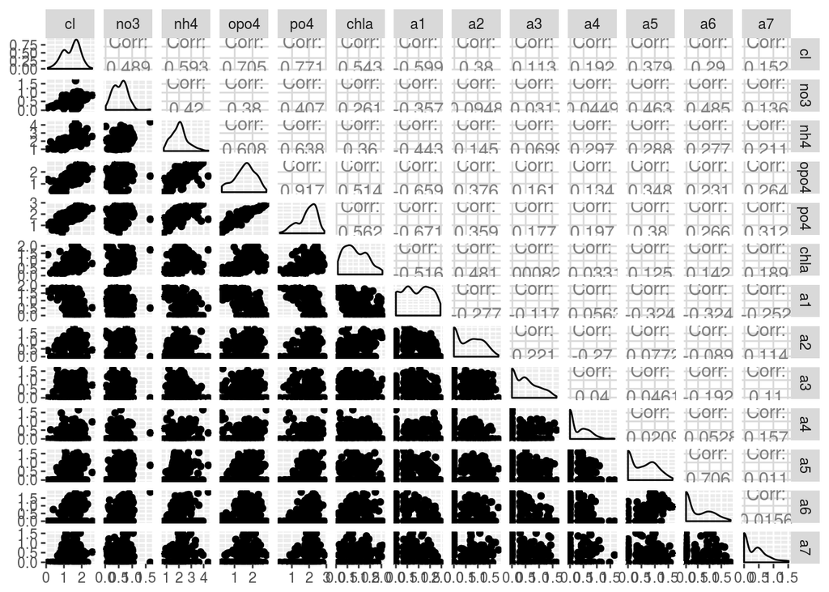

Explicacion del proceso en la grafica de missings podemos observar cuales son las variables que tienen NA’s de forma grafica en este caso observamos que estas son chla y cl en su mayoria junto con po4,opo4,nh4,no3,min_o2y max_ph en menor cantidad.

Luego, podemos observar la matriz de correlaciones de valores NA’s donde de esta grafica podemos interpretar que los variables no3,nh4 y opo4 son missings al parejo es decir si una de ellas es missing las otras 2 tambien lo seran. tambien pasa un eefecto similar con las variables cl y chla.

Después si observamos la primera gráfica de variables podemos ver en la diagonal para las variables numéricaslas distribuciones de estas es importante este punto dad que las imputaciones de valores missing se hicieron basadas en las distribuciones de variables arriba mencionadas de a siguiente forma con su justificación: 1.-imputar max_ph con la mediana porque su distribucion es quasi normal.. 2.-imputamos po4 haciendo una regresión lineal con opo4 porque su relacion es casi lineal(ver gráfica). 3.-imputamos cl, chla y min_o2 con 3-vecinos mas cercanos dado que sus distribuciones estan sesgadas.

y finalmente si revisamos la el último ggpairs podemos ver las variables se transformaron dado que max_ph se distribuye casi normal solo la vamos a estandarizar, min_o2 no tienen tanto sesgo tambien la estadirizaremos

al resto de las variables numericas las transformaremos en logaritmo+1 dado que solo tienen valores positivos y estan sesgadas esta funcion abre valores pequeños y agrupa valores grandes.. esto último se nota en último ggpair.

Finalmente mostramos el GEDA de la interacción entre variables…

```r
source('03-eda.R')
```

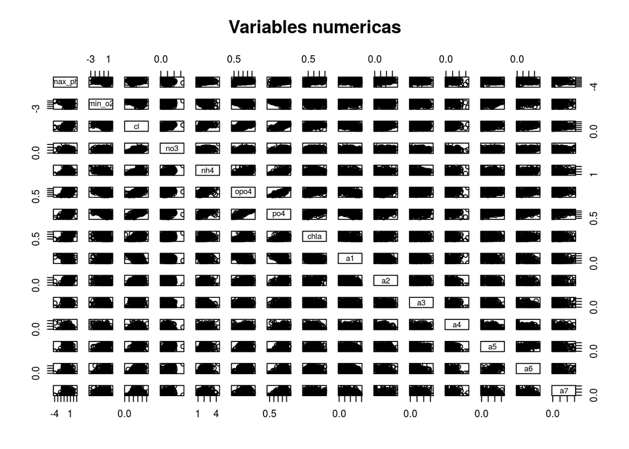

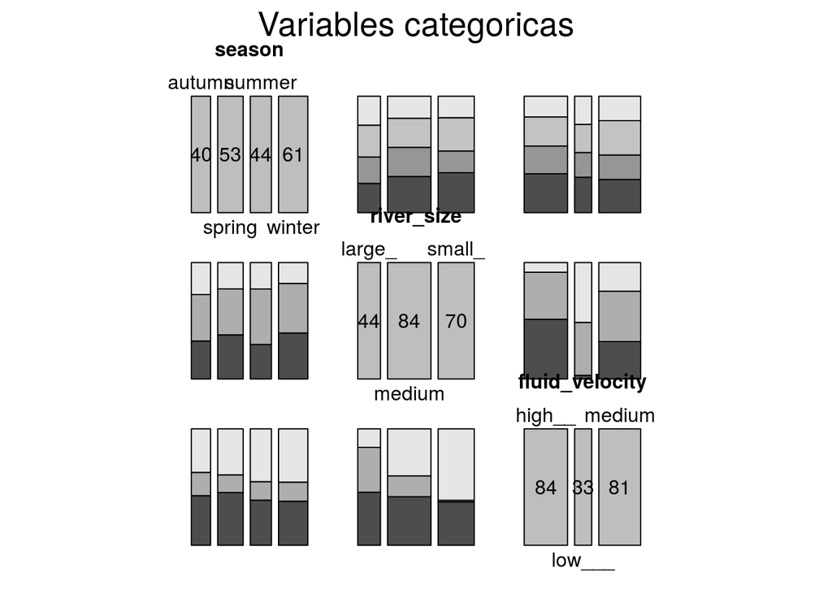

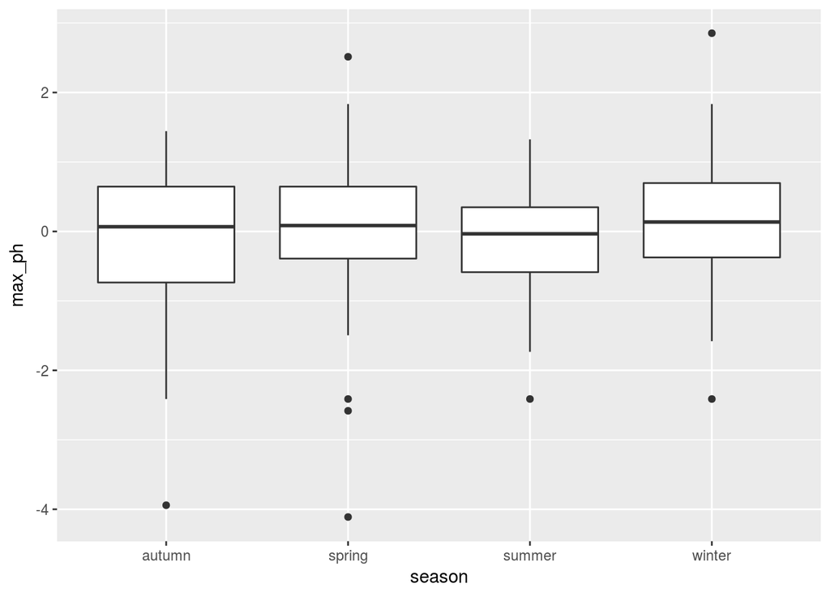

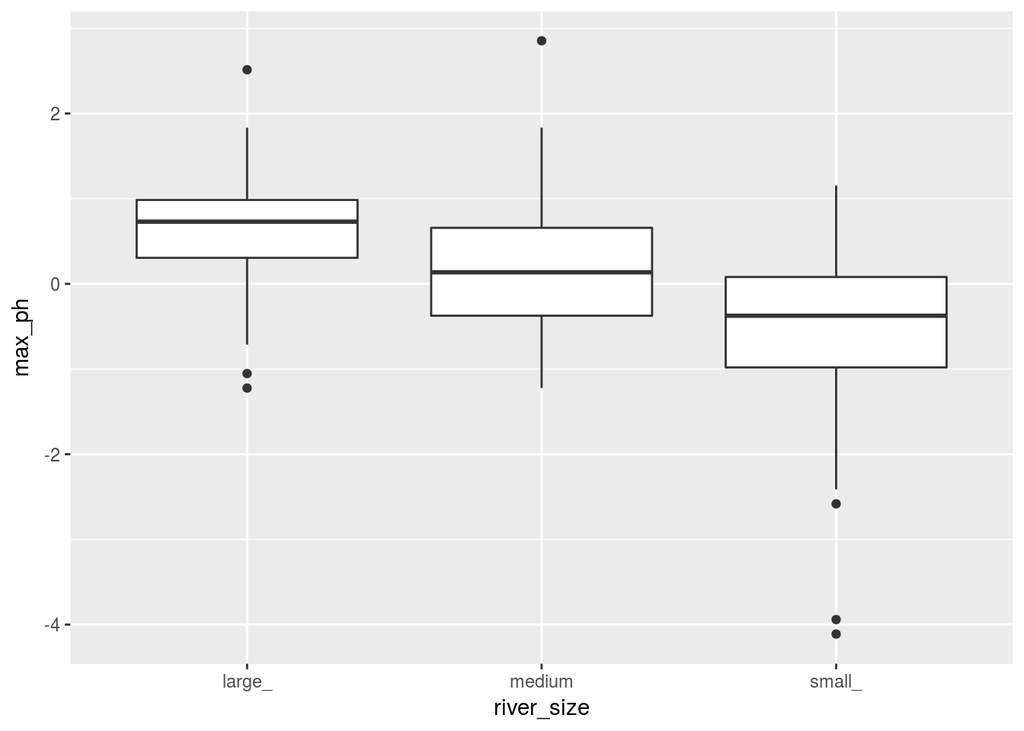

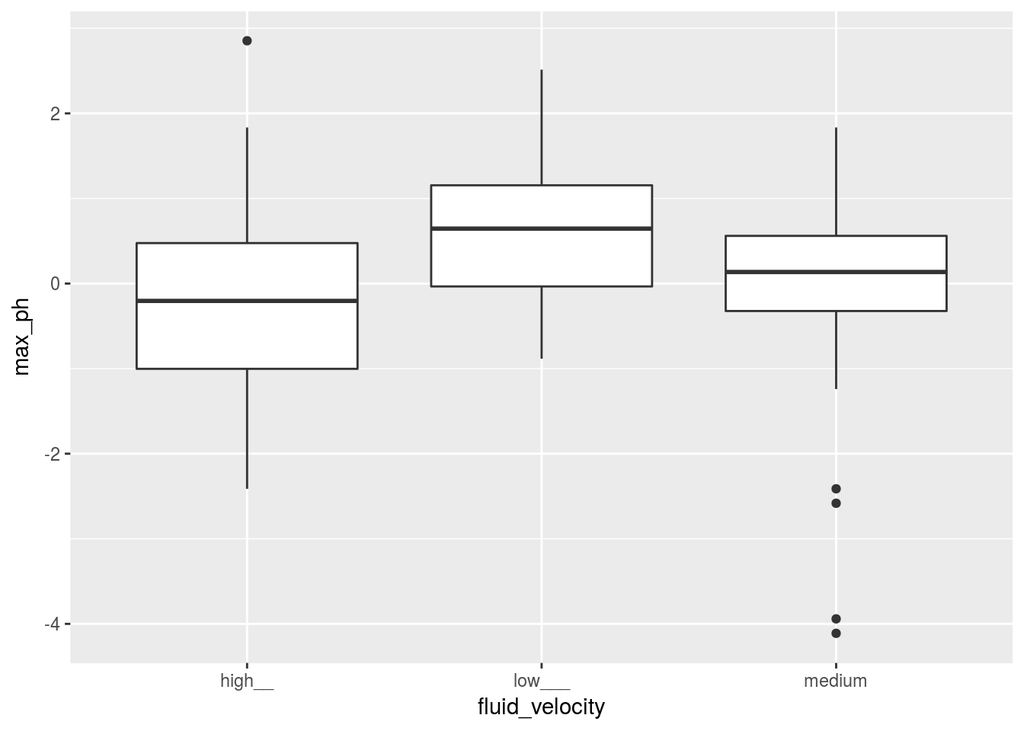

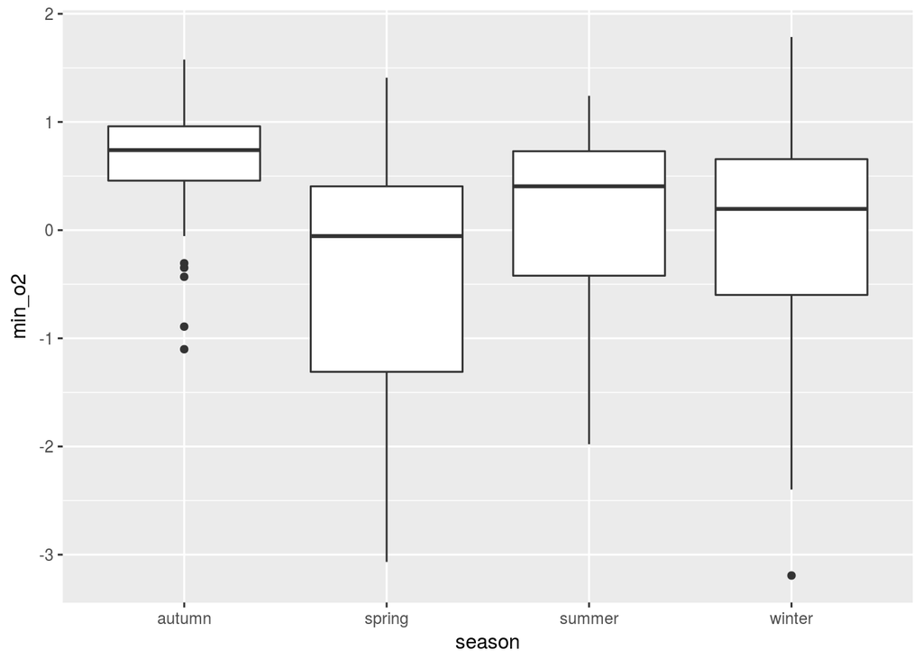

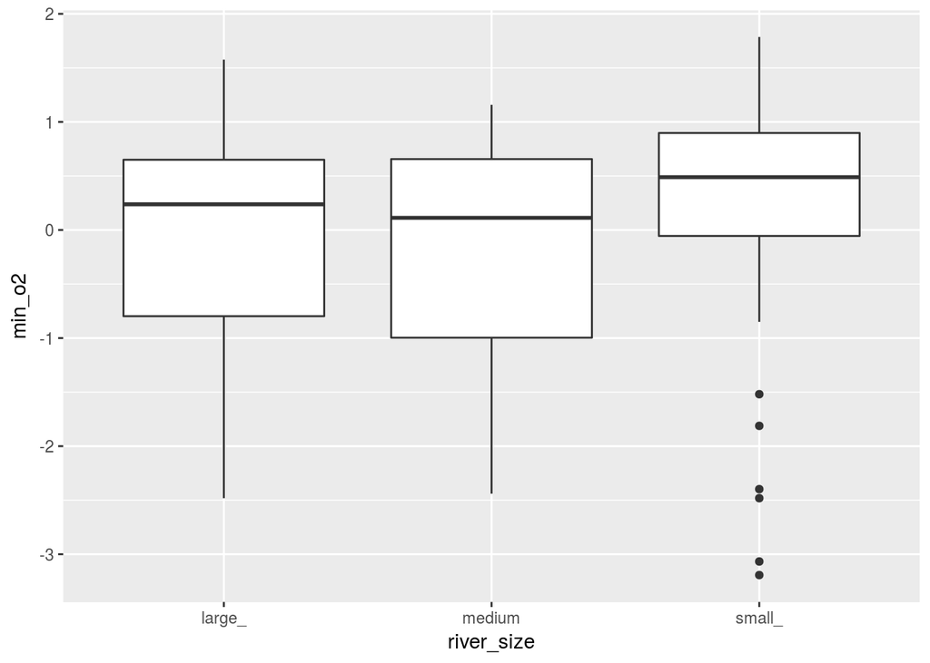

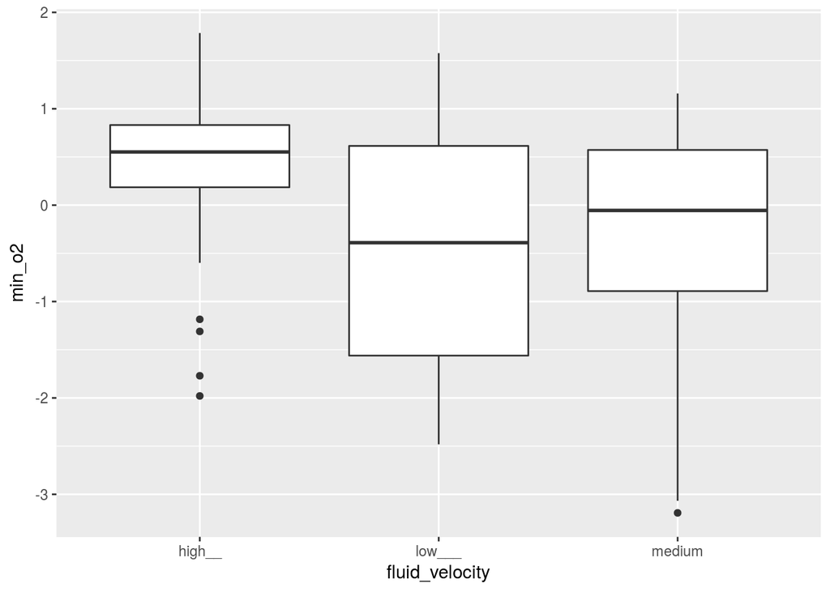

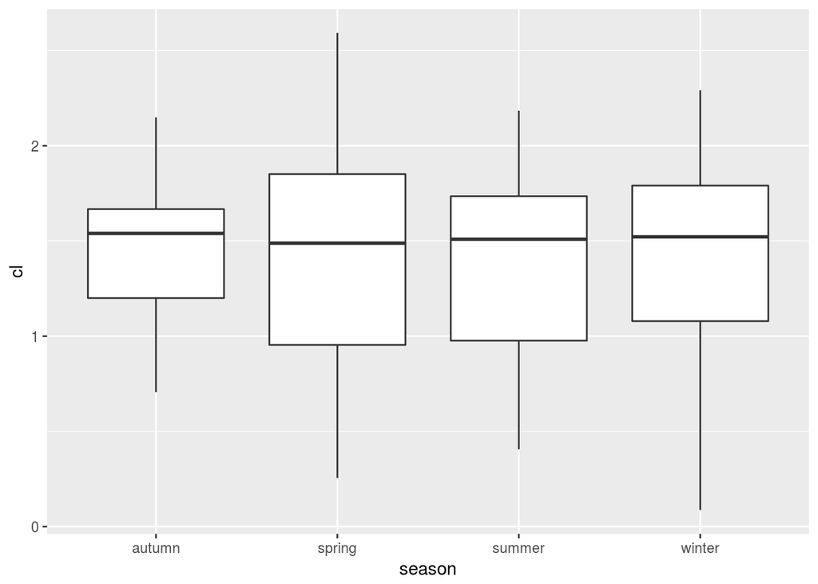

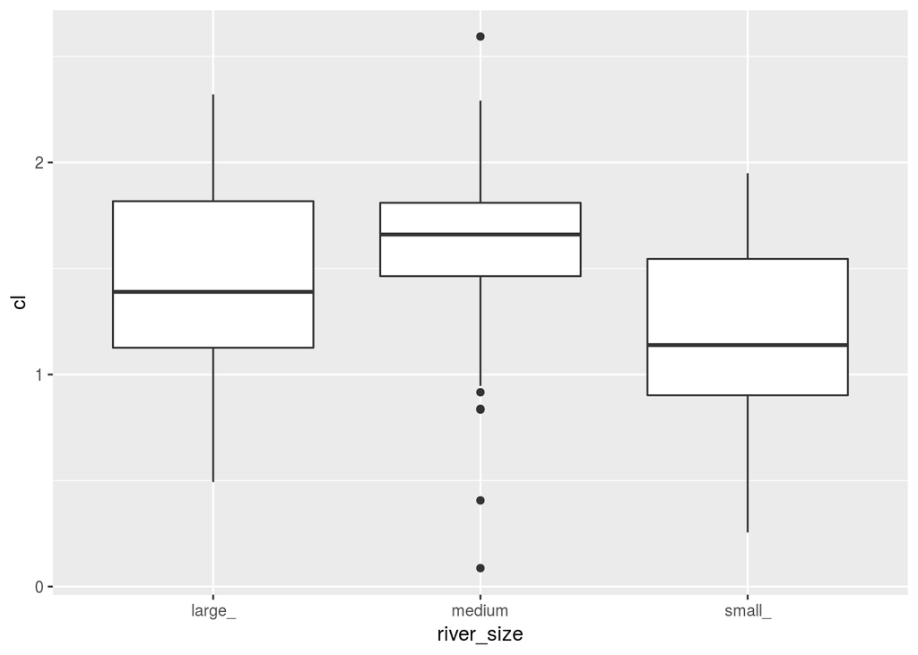

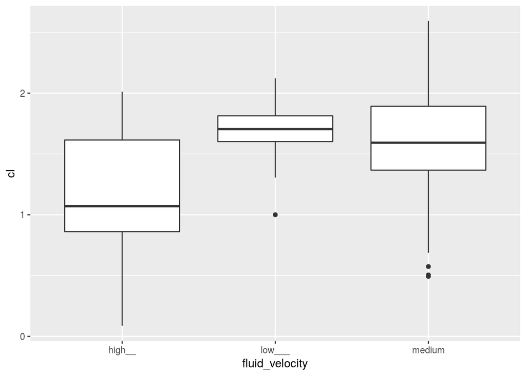

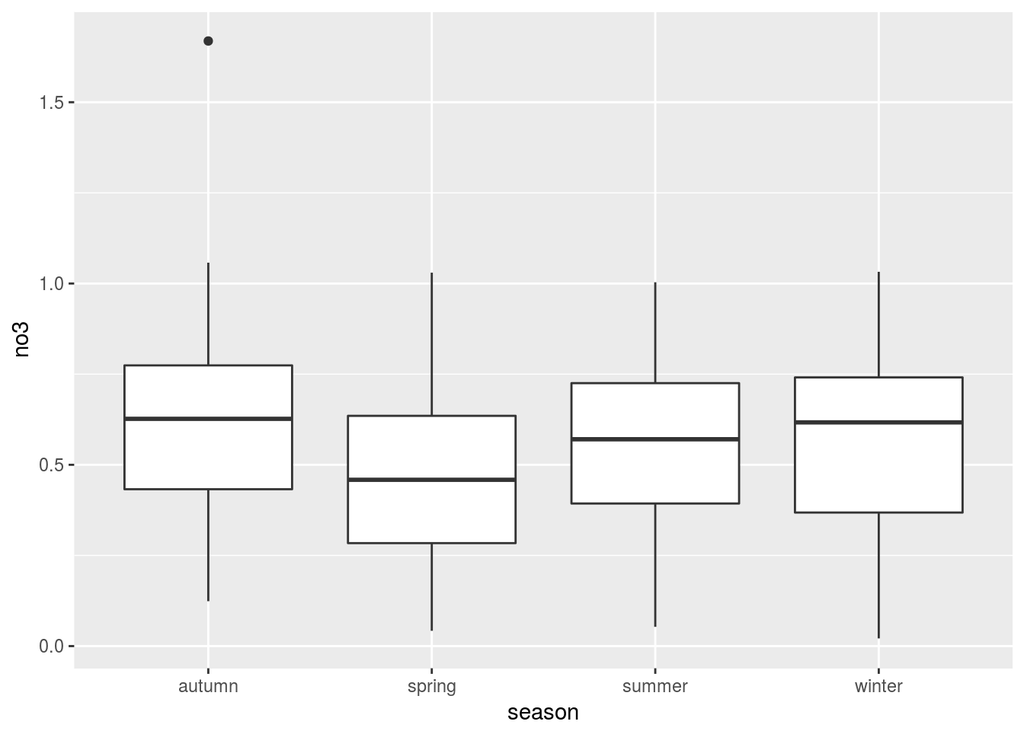

[35 more figures not shown]

Con la manipulación de datos podemos ver que algunos outliers desaparecieron aunque la mayoría de los restantes aparecen en los boxplots del GEDA.